# LEGO Case Study: Modeling Amazon Price

Draft analysis section • Based on the supplied 1,304-set dataset

## Objective and data preparation

We modeled Amazon price using set characteristics to assess whether they could guide purchasing decisions. We did not use LEGO’s recommended price as a predictor, as required by the assignment. We retained 826 sets with recorded positive Amazon prices and positive piece counts; 478 sets lacked an Amazon price. We did not impute the outcome.

We randomly divided the eligible sets into 660 training sets and 166 test sets using seed 123. We compared models using five-fold cross-validation within the training sample, fitting all preprocessing separately in each fold. We then evaluated the selected model on the test sample. These are random-split estimates, not a validation on future release years.

For numeric predictors with missing values, we used training-sample medians. Minifigure counts were transformed using log(1 + count), and a separate indicator identified missing counts. This avoided interpreting every missing count as zero: the data documentation states that NA can indicate either zero or unknown. Missingness indicators were included only when at least five training observations were missing; rarer missing values were median-imputed without a separate indicator to avoid fitting singleton categories. Missing themes were labeled Unknown, and themes represented by fewer than 15 training observations were pooled as Other. All rules were reapplied within cross-validation folds.

## Candidate models

We compared five linear regression specifications. The baseline predicted raw price from piece count. The second predicted log price from log piece count. The structure model added log(1 + minifigures), minimum age, release year, and brick size. The theme model replaced brick size with theme, because DUPLO theme and large brick size encode overlapping information. The construction model additionally included log instruction pages and log unique-piece count. We excluded identifiers and names, and omitted weight because it was missing for 865 of 1,304 sets. Availability and packaging were not included in this initial candidate set; the results do not establish that they lack predictive value.

For log-response models, we converted predictions to dollars with a training-residual smearing correction: predicted price = exp(predicted log price) × mean(exp(training residual)). This accounts for the fact that simply exponentiating the fitted log value does not generally estimate mean dollar price. A single smearing factor is still an approximation when residual variability changes across sets.

## Model comparison

| Model | CV RMSE ($) | CV MAE ($) |
| --- | --- | --- |
| Raw price: pieces | 39.893 | 22.895 |
| Log price: log pieces | 46.039 | 25.257 |
| Log price: structure | 37.867 | 19.948 |
| Log price: theme | 35.736 | 18.604 |
| Log price: theme + construction | 35.176 | 18.212 |

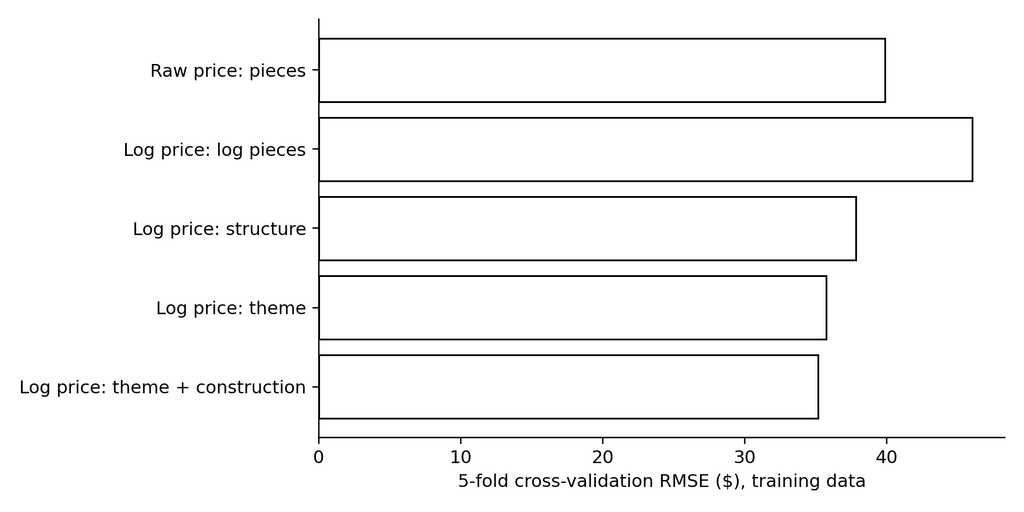

The theme-and-construction model had the lowest cross-validated RMSE ($35.18) and MAE ($18.21). Its RMSE advantage over the theme model was only about $0.56, so the improvement from construction details was modest. We selected it by the prespecified lowest-RMSE rule, rather than by training R-squared or test-set performance. A log transformation alone did not improve dollar-scale prediction: the log-pieces-only model performed worse than the raw-price baseline.

## Selected model and interpretation

The fitted training model was:

log(Amazon price) = 0.333 + 0.312 log(pieces) + 0.376 log(1 + minifigures) + 0.066 minimum age + 0.108 log(pages) + 0.117 log(unique pieces) + year effects + theme effects + missingness indicators.

Natural logarithms were used. City and 2018 are the reference categories for theme and year. The training smearing factor was 1.111. Holding the other included variables fixed, a 10% increase in pieces was associated with approximately 3.0% higher fitted geometric-mean price. A one-year increase in minimum recommended age was associated with approximately 6.8% higher fitted geometric-mean price. Increasing minifigures from two to three was associated with approximately 11.4% higher fitted geometric-mean price. These are adjusted associations, not causal effects or evidence that adding a component would change a set’s market price by that amount.

Piece count, unique pieces, pages, and age can overlap substantially in what they describe. Their coefficients therefore represent conditional comparisons, rather than the overall relationship shown in the EDA. The robust interval for the unique-piece coefficient included zero, so its separate association was uncertain. Year effects describe this historical dataset and should not be treated as a reliable annual pricing trend.

### Selected coefficients with 95% HC3 robust intervals

| Term | Estimate | CI_low | CI_high |
| --- | --- | --- | --- |
| log_pieces | 0.312 | 0.155 | 0.469 |
| log1p_minifigures | 0.376 | 0.227 | 0.524 |
| log1p_minifigures_missing | -0.260 | -0.396 | -0.123 |
| minimum_age | 0.066 | 0.041 | 0.091 |
| log_pages | 0.108 | 0.051 | 0.165 |
| log_pages_missing | 0.220 | -0.125 | 0.564 |
| log_unique_pieces | 0.117 | -0.099 | 0.333 |
| Year_2019 | -0.434 | -0.522 | -0.346 |
| Year_2020 | -0.611 | -0.701 | -0.521 |

These intervals describe the selected training specification. They do not account for model-selection uncertainty, nonrandom data collection, or uncertainty from imputation. HC3 standard errors address unequal residual variance in coefficient inference; they do not repair inaccurate predictions or produce valid individual prediction intervals by themselves.

## Held-out prediction accuracy

| Measure | Value |
| --- | --- |
| Test RMSE ($) | 53.643 |
| Test MAE ($) | 23.006 |
| Test R-squared | 0.203 |
| Training-mean baseline test RMSE ($) | 60.094 |

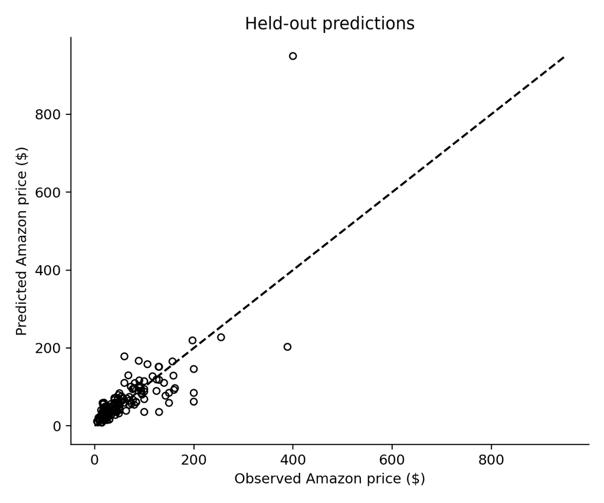

On the 166 held-out sets, average absolute prediction error was $23.01 and RMSE was $53.64. Test R-squared was 0.203, indicating limited dollar-scale predictive accuracy. The model improved on predicting the training mean for every set (RMSE $60.09), but large errors remained. In particular, Hogwarts Castle had an observed price of $399.99 and a predicted price of approximately $949.47. The much larger RMSE than MAE reflects the influence of several large errors. We retained these test cases in all reported metrics.

## Diagnostics and sensitivity

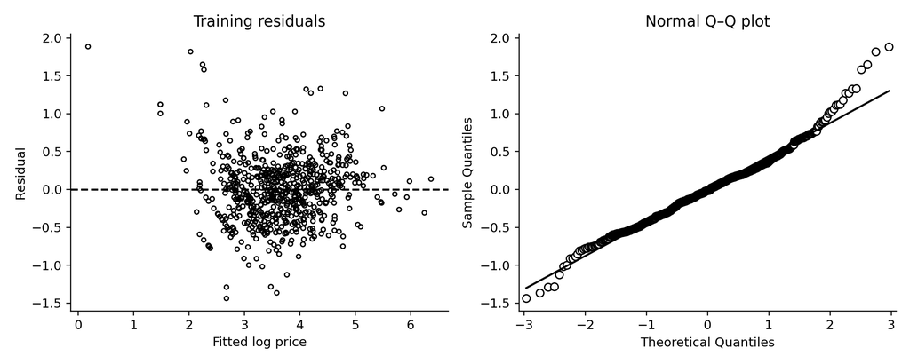

The residual and Q–Q plots show departures from ideal linear-model assumptions, including tail departures. The Breusch–Pagan test also indicated unequal residual variance (p < 0.001). We consequently report HC3 robust coefficient intervals and emphasize held-out dollar errors rather than relying on normal-error assumptions. We have not supplied conventional individual prediction intervals because their coverage has not been established for these data.

The largest training Cook’s distance was approximately 0.098 for White Baseplate. In a sensitivity fit excluding that observation, test RMSE changed from $53.64 to $49.93. We retained it in the primary analysis because influence alone is not evidence of a data error. This check demonstrates sensitivity; it was not used to select the final model.

## Limitations and conclusion

We found that theme, age, minifigures, and construction characteristics improved cross-validated prediction compared with piece count alone. However, the selected model is best treated as an initial pricing guide rather than a dependable valuation tool. Its performance on unusual or expensive sets was uneven. Only 63.3% of the original dataset had an Amazon price, and coverage was much higher for retail sets than LEGO-exclusive sets. Our findings therefore apply most directly to sets with recorded Amazon prices in this dataset.

The data cover sets released in 2018–2020 and do not establish accuracy for today’s market or future release years. Because these data have already been explored in our EDA, the test set is an internal validation sample rather than a completely untouched external sample. A useful next step would be to compare a regularized model and a model allowing nonlinear relationships, using a new validation design. The existing test results should not be repeatedly used to tune improvements.

Source: supplied “case-study2 (1).pdf” assignment and “case-study2-data (1).csv.” Calculations performed in Python using statsmodels and scikit-learn. This is a draft modeling analysis for group review, with all observed test errors retained.